# UF CAMPAS Master Series Classes

Power analysis & Selecting appropriate statistical models

Caleb Huo

Thur June 18, 2020

# Outline

- Power analysis
  - Softwares
  - Theories
- Selecting appropriate statistical models
- Expectation after this lecture:
  - Know how to do power calculation using softwares, and write sample size justification in your proposal
  - Have a basic idea how to deal with different kinds of data

*Please interupt me at any time if you have any question.*

# Power analysis

- The role of power analysis in your proposal.
  - If you don’t have power analysis/sample size justification, your proposal score will be deducted.
  - But it won’t be a dominating factor of your proposal.
- Have you ever included sample size justification in your proposal?
  - If so, how did you do it?

# Softwares

1. GPOWER
2. PASS
3. (Or) Find a statistician

# GPOWER

[figure not shown]

- GPOWER is a free software to do power calculation.
- The following statistical tests are included:
  - t-tests
  - F-tests
  - Chi-square tests
- GPOWER website
  - https://www.psychologie.hhu.de/arbeitsgruppen/allgemeine-psychologie-und-arbeitspsychologie/gpower.html

# Screen shot of GPOWER

[figure not shown]

# Demonstration of GPOWER

Two most commonly encountered scenarios

- Means: Difference between two independent means (two groups).
  - Under t test
- Difference between two different proportations.
  - Under z test

# PASS

[figure not shown]

- PASS is very powerful, but not free
  - Including power calculation for various scenarios
- PASS website
  - https://www.ncss.com/software/pass/
- Question:
  - Name any statistical test you can imagine?

# (Or) Find a statistician

- Benefit:
  - provide consulting service
  - customize to your data or proposal
- cost:
  - some consulting fees
  - usually, this is also done through collaborations

# Comparison of different approaches

| Method | Basic | Complex | Free | Customize |
| --- | --- | --- | --- | --- |
| GPOWER | Y |  | Y |  |
| PASS | Y | Y |  |  |
| Statistician | Y | Y |  | Y |

# Theories underlying Power Analysis

- What is power?
- What will affect power?
- Frequently asked question about power analysis.

# Hypothesis testing

- Null hypothesis: the treatment has no effect (true effect = 0)

If we measure the effects under the null many times in different studies, the observed effects have a distribution around the true effect because the population are heterogeous

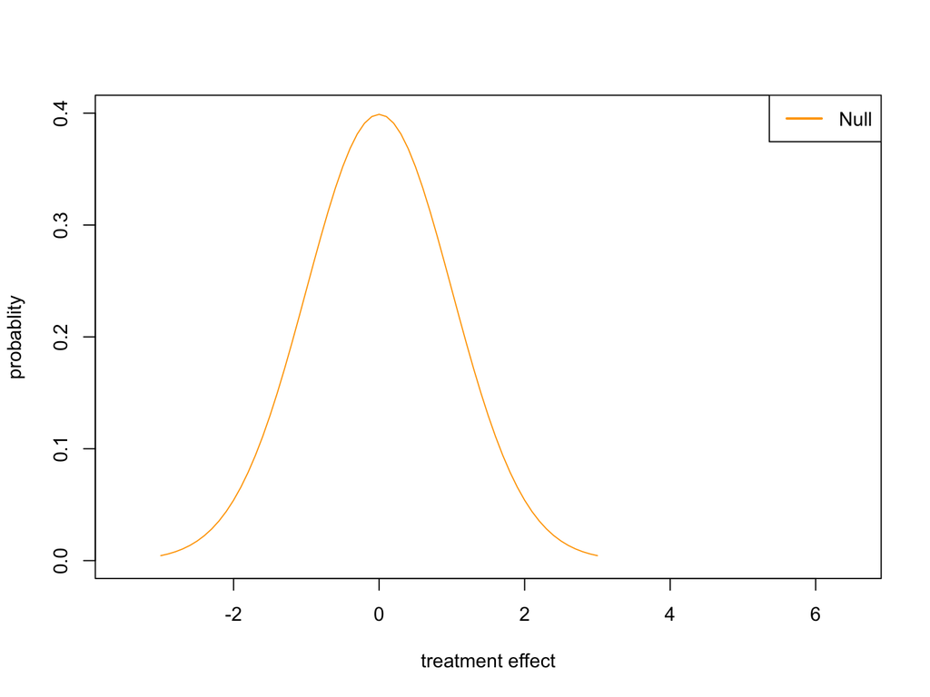

# Hypothesis testing

- Alternative hypothesis: the treatment has an effect (true effect = 3)

If we measure the effects under the alternative many times in different studies, the observed effects have a distribution around the true effect because the population are heterogeous

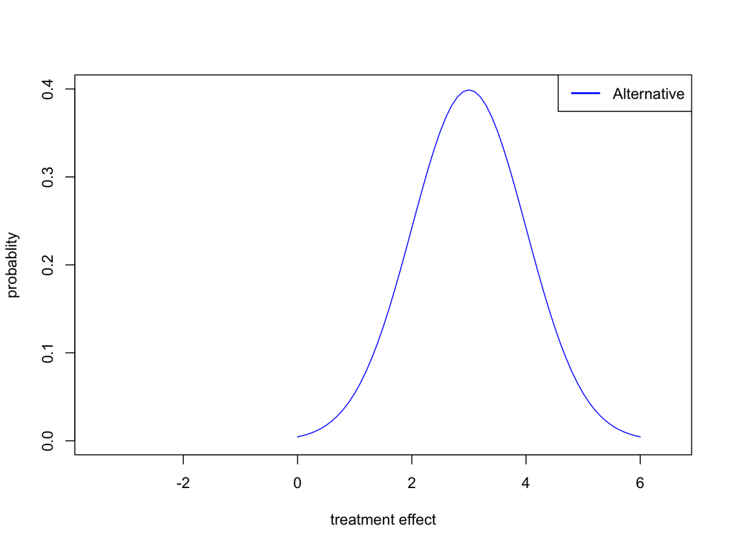

# Hypothesis testing

- Null hypothesis: the treatment has no effect (true effect = 0)
- Alternative hypothesis: the treatment has an effect (true effect = 3)

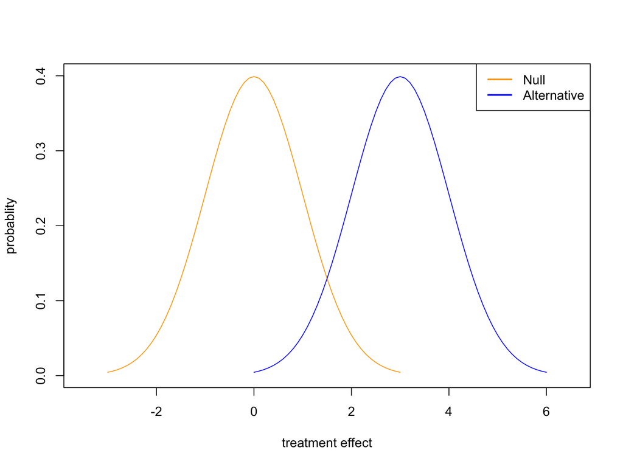

# Decision rule

- Decision rule: we want to set up a rule to make a decision
  - Test Positive:
    - to the right of the decision cutoff
    - our decision is to reject the null hypothesis, and we declare there is an effect
  - Test Negative:
    - to the left of the decision cutoff
    - our decision is not to reject the null hypothesis, and we declare there is no effect

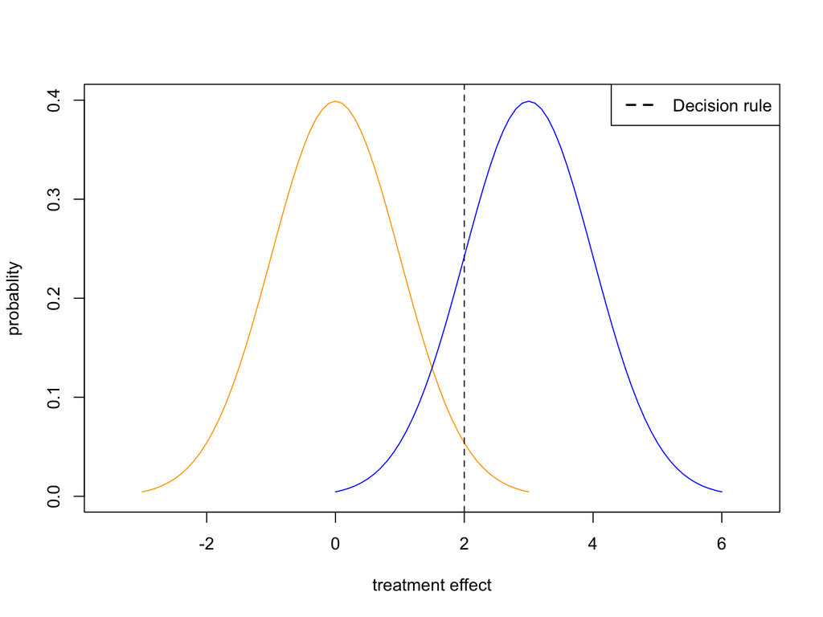

# Decision rule, Scenario 1

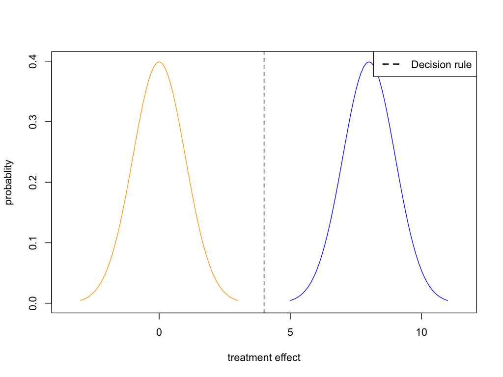

When the two curves are perfectly separated, then it is easy to make a decision. And our decision will be correct.

| Truth | Test positive | Test negative |
| --- | --- | --- |
| Null | 0 | 100% |
| Alternative | 100% | 0 |

# Decision rule, Scenario 2

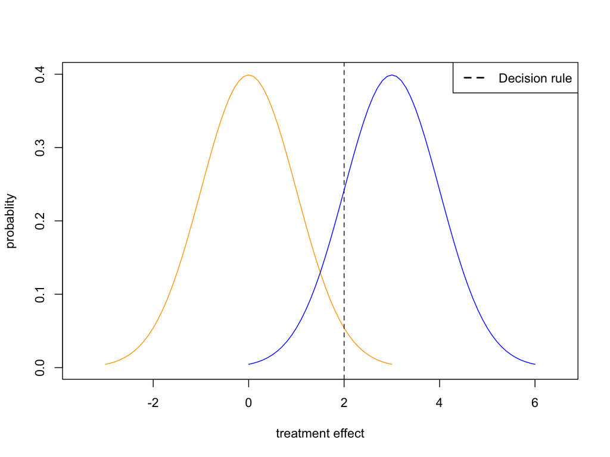

When the two curves are not separated, then it is not easy to make a decision. In another word, no matter what decision we make, we will make some mistakes.

| Truth | Test positive | Test negative |
| --- | --- | --- |
| Null | false positive | true negative |
| Alternative | true positive | false negative |

# Definition of power (1)

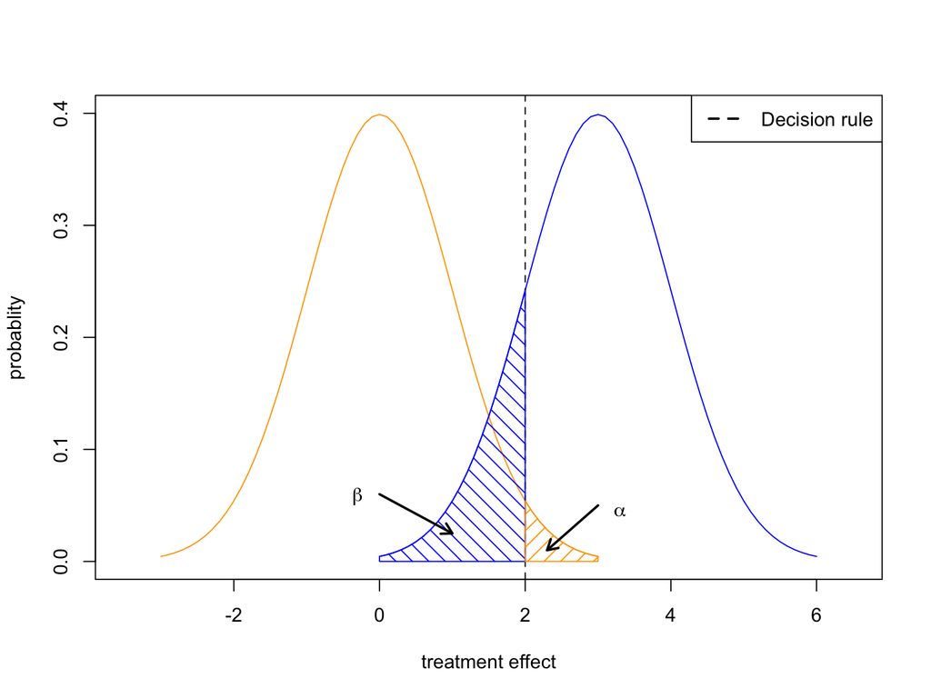

- $\alpha$:
  - Type I error rate, false positive
  - orange shaded area, given the null hypothesis is true, the probability we falsely reject the null.
- $\beta$:
  - Type II error rate, false negative
  - blue shaded area, given the alternative hypothesis is true, the probability we fail to reject the null.

# Definition of power (2)

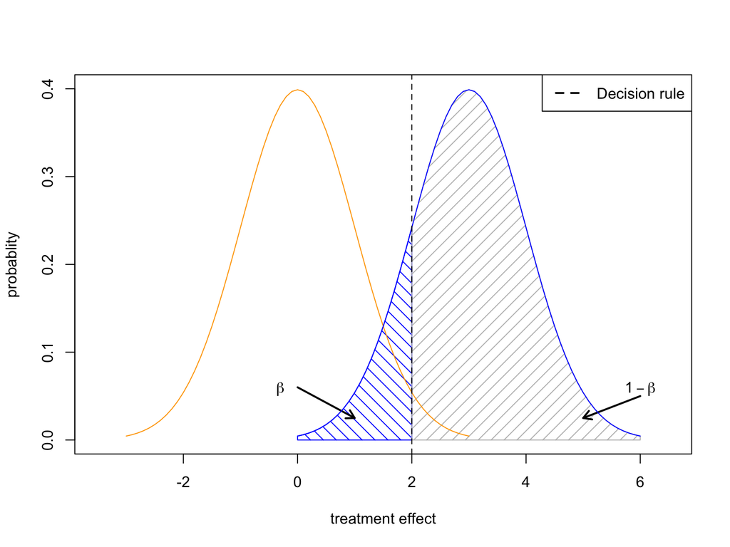

- Power:
  - $1 - \beta$
  - 1 - Type II error rate
  - grey shaded area, given the alternative hypothesis is true, the probability we reject the null.

# Another view of power

| Truth | Test positive | Test negative |
| --- | --- | --- |
| Null | false positive | true negative |
| Alternative | true positive | false negative |

- Power = true positive / (total alternative)

# What are the factors that could influence power?

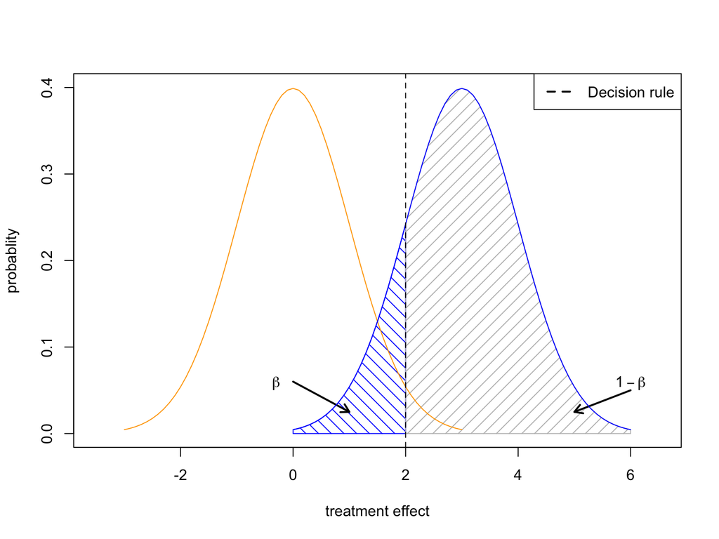

The following factors will influence power

- Decision rule
- Effect size: the separation of null and the alternative
- Sample size

# Decision rule

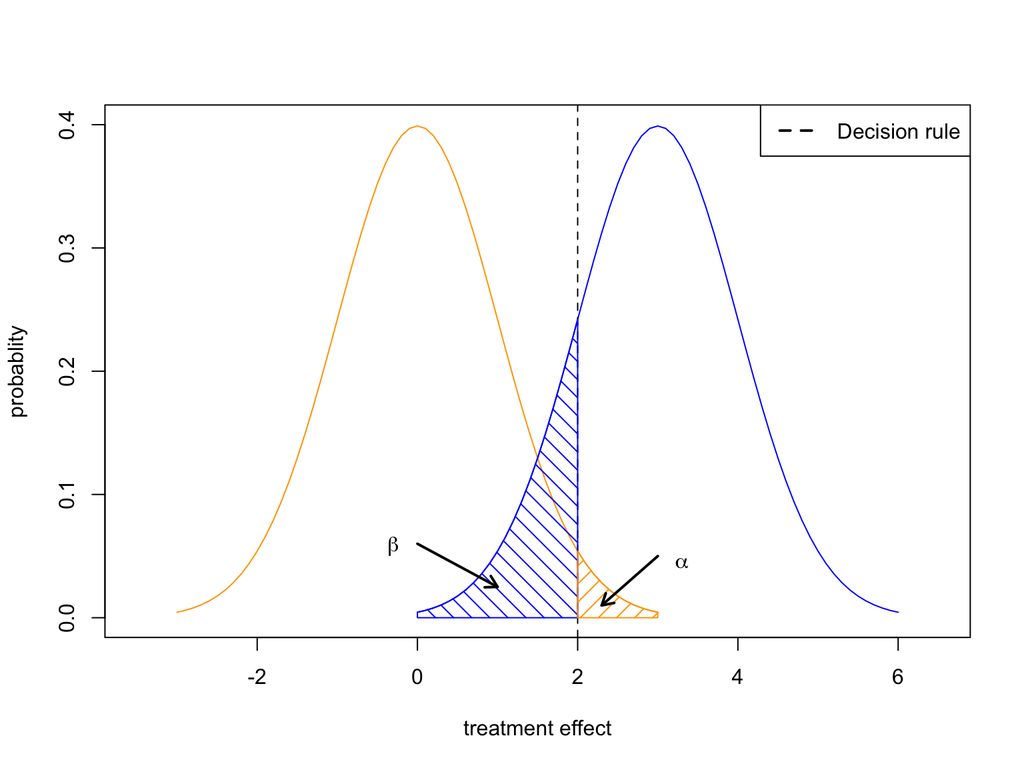

- Usually, people tend to set the decision rule such that $\alpha = 0.05$.
- Recently, people are debating whether we should stick with $\alpha = 0.05$, but still, it is the most widely used decision rule in the literature.

# Effect sizes

- Effect size d = mean difference / pooled standard deviation
  - Placebo group: $\mu_1$, $\sigma_1$, $n_1$
  - Treatment group: $\mu_2$, $\sigma_2$, $n_2$
  - mean difference = $\mu_2$ - $\mu_1$
  - pooled standard deviation

$$\sigma_{pooled} = \sqrt{\frac{(n_1 - 1) \sigma_1^2 + (n_2 - 1) \sigma_2^2}{n_1 + n_2 - 2}}$$

# Cohen’s Effect sizes

Cohen’s D

| Cohen’s d effect size | Value |
| --- | --- |
| Small | 0.2 |
| Medium | 0.5 |
| Large | 0.8 |

- If you don’t have pilot data to do sample size calculation, you could assume Cohen’s D effect size to justify sample size.

# Sample size $n$

- Larger sample size will help narrow the varaince of the distribution

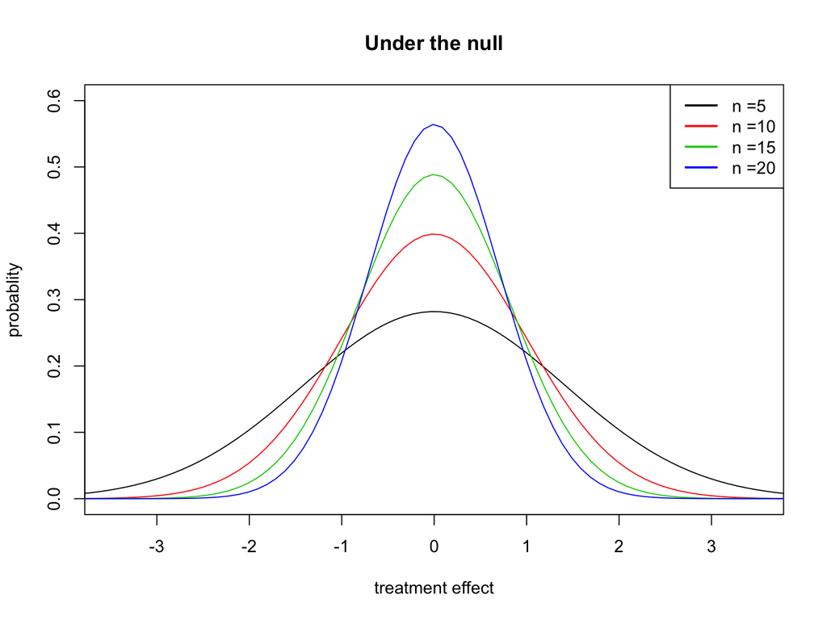

# Sample size $n$ and power

- $\alpha$ is fixed at 0.05

[figure not shown]

# How do different factors impact power

- Sample size $n$
- Effect size
- Type I error rate: $\alpha$ level

# How descript power calculation in the proposal

- Descriptions

In our pilot data, the mean difference of the treatment group and placebo group is XX. Given the pooled standardization XX, the Cohen’s d effect size is d = XX. At alpha level 0.05, using a two-sided two sample t-test, and considering 20% attrition rate, in order to acheive power 80%, we need to enroll n=XX participants per group. And at least 0.8XX participants are expected to be enrolled after considering attrition.

- Power trajectory (Replace Cohen’D with your own effect size)

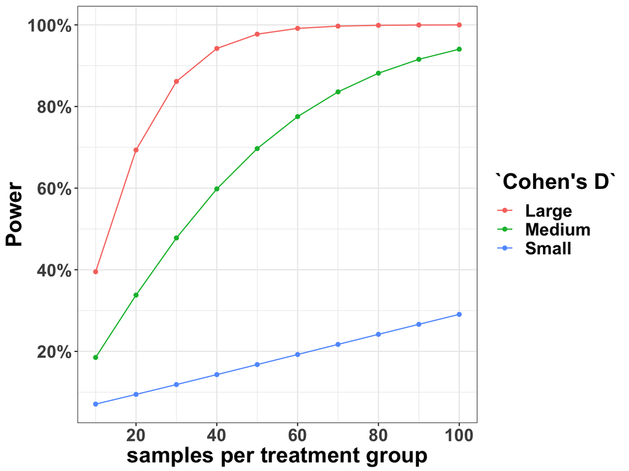

# Frequently ask question (pilot study)

- Pilot study doesn’t need power analysis.
- But sample size justification is still needed.
  - Based on feasibility (e.g., recruiment, implementation), adverse event, etc
- Rule of 12 for continuous outcome:
  - Julious, S. A. (2005). Sample size of 12 per group rule of thumb for a pilot study. Pharmaceutical Statistics: The Journal of Applied Statistics in the Pharmaceutical Industry, 4(4), 287-291.
- Rule of 10 for binary outcome:
  - Van Belle, G. (2011). Statistical rules of thumb (Vol. 699). John Wiley & Sons.

# Frequently ask question (larger observational study/clinical trial)

- If you have pilot data:
  - Use the effect size from the pilot data to perfrom sample size calculation. (Strong justification)
- If you do not have pilot data:
  - Search the literature to find the effect size (Strong justification)
  - Use Cohen’s D effect size (weak justification)
  - If you want to use any effect size: assuming the between group variability is 75% of the group mean difference (e.g., d = mean diff / sd). (weak justification)

*Note: It is better practice to use these strong justificaitons.*

*If not, in my experience you could still use these weak justifications. Though weak, I didn’t see reviewers critisized on these justification.*

# Frequently ask question (Attrition rate)

- If the power analysis needs 100 subjects with complete data
- The dropout rate is 20%.
- Then we need to recruit 100/80% = 125 subjects.

# Questions?

# Selecting appropriate statistical models

Do a survey: what statistical software do you use?

- SPSS
- STATA
- SAS
- R
- Others

Another question: what kind of data you feel hard to analyze?

# Univariable regression setting

One outcome variable (Y), one predictor (X).

- Y is continuous, X is continuous:
  - Pearson correlation test
  - Spearman correlation test (non-parametric)
- Y is continuous, X is binary:
  - Student t-test
  - Wilcoxon rank sum test (non-parametric)
- Y is continuous, X is categorical:
  - ANOVA
  - Kruskal–Wallis test (non-parametric)
- Y is binary, X is binary:
  - $\chi^2$ test
  - Fisher’s exact test

Parametric tests are more powerful, but they require Y has Gaussian distribution

# Multivariable Regression setting

One outcome variable (Y), one predictor (X, continuous), and adjusing several covaraites.

Common type of outcome variables:

- Continious:
  - linear regression
- Binary (0,1)
  - logistic regression
- Category (A, B, C)
  - multilevel logistic regression
- Ordinal (0, 1, 2, …)
  - ordinal logistic regression
- Count data (0,7,101,…)
  - Possion regression
  - Negative bionomial regression
- Survival (time, event)
  - Cox regression

These models, except for the Cox regression, are often referred as generalized linear models (GLM).

# Repeated measured outcome variable

- Longitudinal data
  - Same subject has repeated measurement from multiple visits
- Correlated data
  - Family: different people from the same family are probably correlated
  - Center

Statistical solution:

- Mixed models
- Generalized estimating equations (GEE)

# Combination of GLM and mixed models/GEE

Part A + Part B

- Part A: GLM
  - linear regression
  - logistic regression
  - multilevel logistic regression
  - ordinal logistic regression
  - Possion regression
  - Negative bionomial regression
- Part B: Correlation structure
  - mixed model
  - GEE

Some examples:

- linear mixed model:
  - linear regression + mixed model
- mixed effects logistic regression:
  - logistic regression + mixed model
- generalized linear mixed models (GLMM):
  - GLM + mixed model
- linear regression + GEE
- logistic regression + GEE